# Text as Data: Words, Weights and Context

A Course on Data Visualization

Livio Finos, University of Padova

# 1 The question we will investigate

**Main question:** How do our choices about representing text change what we see?

Units 11 and 12 compared objects through distances. We now need to decide what the measurements of a text document should be. Before making a map, we will read texts, count words, choose weights, and check how much context is lost.

Use these notes during class and keep them for review. Every worked BBC example is followed by a task on **a different corpus: SMS messages**. This transfer is deliberate: short informal messages need not behave like news articles.

A **token** is one occurrence of a small piece of text produced by a splitting rule. In this unit, think of it informally as a **word occurrence**: `tea tea cake` contains three tokens, even though it has only two different word forms. **Tokenisation** means splitting text into these units. We will examine the precise splitting and filtering rules later; this first definition lets us describe document length before studying those choices.

## 1.1 Learning goals

- Define a document, a token, metadata and a document-term matrix (DTM).
- Explain how tokenisation and vocabulary filtering alter the data.
- Distinguish counts, relative frequencies and TF-IDF weights.
- Compare word clouds with ordered bars and interpret n-grams in context.
- Read directed bigram networks and use their paths to propose longer phrases that can be checked in the original texts.
- Keep a reproducible record of decisions and their consequences.

## 1.2 What you need

**Prerequisites:** R indexing, tables, proportions, simple plots and matrices. **R packages:** `ggplot2`, `knitr` and `rmarkdown`. The inspectable helpers in `data/text_helpers.R` use base R; no specialist text-mining package is required.

Open the course folder (the folder containing these Rmd files and `data/`). Keep a script called `13_my_text_lab.R`. Append an answer after each activity; do not overwrite earlier results when changing a setting. A useful entry is **prediction -> code -> output -> interpretation -> limitation**.

# 2 Data and context

The guided corpus contains 250 **real BBC articles**, 50 in each of five topics. Your activity corpus contains 240 **real SMS messages**, 120 labelled `ham` (ordinary messages) and 120 `spam`. Exact text duplicates were removed before sampling. The full downloaded archives contained 2,225 BBC articles and 5,574 SMS rows; after exact-text deduplication, 2,127 and 5,171 unique texts remained.

One complete article or message is one document. Sentences are temporary units for extracting adjacent words; they will not become separate MDS points.

| Column | Meaning | Analytical role |
| --- | --- | --- |
| `document_id` | Unique retained document | Row label |
| `text` | Original complete text | Source of features |
| `category` | BBC topic or SMS label | Metadata; excluded from word features |
| `source_id` | Original file path or row | Traceability |
| `raw_tokens` | Baseline token count, calculated by the import helper | Derived document-length measure; not an original CSV column |

The files retain the original text. English ASCII-letter tokenisation below is a simple baseline, not a language-independent linguistic parser. These older corpora do not represent all present-day news or messaging.

```r
library(ggplot2)
theme_set(theme_minimal(base_size = 12))
source("data/text_helpers.R")
bbc <- load_text_docs("data/bbc_articles_250.csv")
sms <- load_text_docs("data/sms_messages_240.csv")
```

# 3 Begin with documents, not with a cloud

Read a few articles before calculating summaries. Check identifiers, category counts and length. The import helper creates `raw_tokens`: the **number of baseline word tokens in each complete document**, counting repeated occurrences. For this initial count it lowercases text, recognises English-letter sequences with internal apostrophes, drops single-letter words and excludes numeric tokens. It has not yet removed stopwords or applied a document-frequency filter.

Thus `raw_tokens` is a document-length measure, not a list of tokens or a count of distinct words. It follows the stated rule rather than a universal definition of a word. We will inspect and change that rule in the next section.

```r
table(bbc$category)
```

```
#>
#>      business entertainment      politics         sport          tech
#>            50            50            50            50            50
```

```r
summary(bbc$raw_tokens)
```

```
#>    Min. 1st Qu.  Median    Mean 3rd Qu.    Max.
#>   108.0   241.0   350.0   383.8   477.8  2257.0
```

```r
head(bbc[c("document_id", "category", "raw_tokens")])
```

|  | document_id | category | raw_tokens |
| --- | --- | --- | --- |
| 1 | bbc_business_006 | business | 172 |
| 2 | bbc_business_026 | business | 283 |
| 3 | bbc_business_059 | business | 281 |
| 4 | bbc_business_062 | business | 297 |
| 5 | bbc_business_075 | business | 203 |
| 6 | bbc_business_077 | business | 443 |

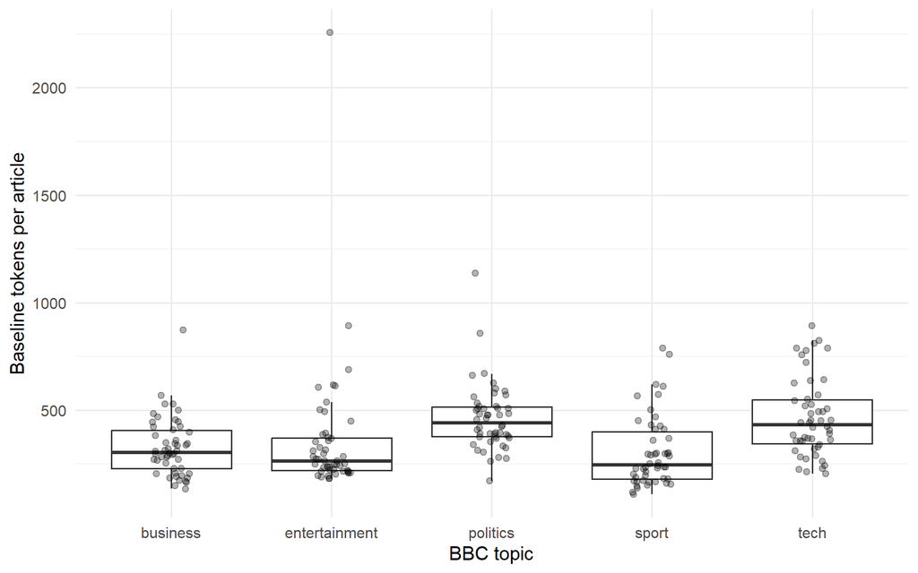

Each point is an article, not a word. Boxplots summarise article-length distributions.

```r
# Read the full first article in the R console when discussing its context:
# cat(bbc$text[1])
ggplot(bbc, aes(category, raw_tokens)) +
  geom_boxplot(outlier.shape = NA) +
  geom_point(position = position_jitter(width = 0.12, seed = 13),
             alpha = 0.3) +
  labs(x = "BBC topic", y = "Baseline tokens per article")
```

**Reading the figure.** The vertical scale is document length. Different topics can have different typical lengths, and documents in the same topic also vary. A larger total word count in a group could reflect longer texts, more texts, or both. Labels are useful for checking our map later, not for defining distance.

## 3.1 Activity A1: Define and audit the observational unit

**Your dataset: SMS. Question:** Are the SMS messages comparable in length and how does their unit differ from a news article?

Before running R, write a prediction and discuss it with a partner. Then:

1. Verify identifiers, missing text and category counts. Read two messages per label.
2. Report median and range of baseline token counts by label and make a length plot.
3. Explain why a balanced sample cannot estimate the prevalence of spam.

```r
table(sms$category)
summary(sms$raw_tokens)
# Add the within-label summaries, plot and four contextual readings.
```

**Record and compare:** save the requested output, explain what it shows in two or three sentences, and compare your prediction with a neighbouring group. Agree on one limitation. Rotate who writes the code and who checks the result.

# 4 Decide what becomes a token

Our `word_tokens()` function lowercases text, recognises letter sequences with internal apostrophes, and discards single-letter words. Its optional numeric-token rule retains digit sequences. Punctuation, emojis, URLs and hyphens are not interpreted semantically; URL pieces can survive as words. Inspect the function before treating its output as a complete description.

A **stopword list** removes selected common words. It is a modelling choice, not an objective definition of useless language. Our short supplied list keeps `no`, `not` and `never`, and removes the honorific `mr`. This domain-specific choice reduces a common form of address; it does not remove people’s names or every reporting expression (`said`, for example, is retained). Check contractions and domain-specific expressions before interpreting meaning or sentiment.

The initial `raw_tokens` measure is calculated before stopword removal, so it still counts occurrences of `mr`. The cleaned unigram vocabulary does not. Removing `mr` also changes the retained-token denominator in articles that contain it, so other terms’ TF and TF-IDF values can change. If the retained document set stays the same, the other unigrams’ document frequencies and IDFs remain unchanged. Recompute the profiles and category summaries rather than just deleting a label from an old graph.

```r
bbc_tokens <- word_tokens(bbc$text)
bbc_clean <- word_tokens(bbc$text, stop_words = course_stopwords)
raw_counts <- term_counts(bbc_tokens)
clean_counts <- term_counts(bbc_clean)
head(raw_counts, 10)
```

|  | term | count |
| --- | --- | --- |
| 1 | the | 6175 |
| 2 | to | 2900 |
| 3 | of | 2300 |
| 4 | and | 2146 |
| 5 | in | 1969 |
| 6 | for | 1120 |
| 7 | is | 956 |
| 8 | that | 916 |
| 9 | said | 870 |
| 10 | on | 856 |

```r
head(clean_counts, 10)
```

|  | term | count |
| --- | --- | --- |
| 1 | said | 870 |
| 2 | not | 370 |
| 3 | people | 274 |
| 4 | new | 257 |
| 5 | more | 254 |
| 6 | year | 215 |
| 7 | one | 205 |
| 8 | after | 192 |
| 9 | best | 159 |
| 10 | first | 159 |

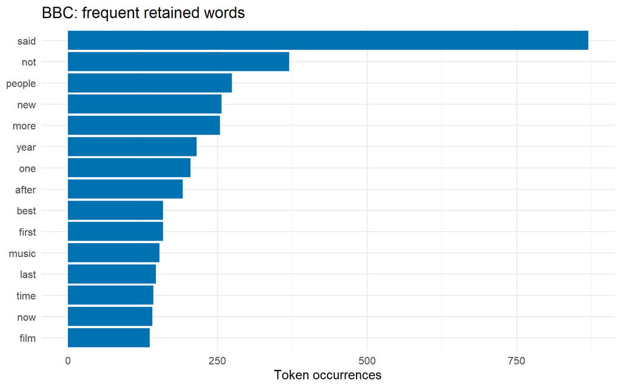

Corpus-level counts: a long article contributes more tokens than a short article.

```r
top_bars(setNames(clean_counts$count, clean_counts$term),
         "BBC: frequent retained words", ylab = "Token occurrences")
```

**Interpretation.** Removal changes both the vocabulary and the denominator of later proportions. A term can become relatively frequent without gaining any occurrences. Names, abbreviations and spelling variants remain separate forms.

**Stemming** reduces related forms to a common stem (possibly not a word). **Lemmatisation** aims at dictionary forms using linguistic information. Neither is applied in the core analysis. For example, combining `run` and `running` changes a column definition; a guessed suffix rule is not reliable lemmatisation.

## 4.1 Activity A2: Change one preprocessing choice

**Your dataset: SMS. Question:** Which aspects of SMS language are lost when common words or numbers are removed?

Before running R, write a prediction and discuss it with a partner. Then:

1. Compare the top ten tokens with and without the supplied stopwords.
2. Holding the stopword rule fixed, compare tokens with `numbers=FALSE` and `TRUE`.
3. Find one affected message and explain what was lost. Audit the list for negation.
4. Use `grep()` on token names to find related word forms; propose one merge and one reason it might be inappropriate. Do not implement guessed lemmatisation.

```r
sms_words <- word_tokens(sms$text)
sms_clean <- word_tokens(sms$text, stop_words = course_stopwords)
# Compare term_counts(), numeric tokens, and an original message.
```

**Record and compare:** save the requested output, explain what it shows in two or three sentences, and compare your prediction with a neighbouring group. Agree on one limitation. Rotate who writes the code and who checks the result.

# 5 From words to a common document-term matrix

Let $C_{it}$ count term $t$ in document $i$. Every row uses the **same vocabulary**. Rows are documents and columns are terms; metadata never enter this matrix. A zero means no retained occurrence, not missing information. Word order has been discarded: this is a **bag-of-words** representation.

```r
toy <- c("tea tea cake", "tea bread", "bread cake")
toy_C <- make_dtm(word_tokens(toy), c("D1", "D2", "D3"), min_df = 1)
toy_C
```

```
#>    bread cake tea
#> D1     0    1   2
#> D2     1    0   1
#> D3     1    1   0
```

```r
bbc_C <- make_dtm(bbc_clean, bbc$document_id, min_df = 2)
c(documents = nrow(bbc_C), terms = ncol(bbc_C),
  zero_fraction = mean(bbc_C == 0), empty_rows = sum(rowSums(bbc_C) == 0))
```

```
#>     documents         terms zero_fraction    empty_rows
#>   250.0000000  5026.0000000     0.9721958     0.0000000
```

**Document frequency** $df_t=\sum_i I(C_{it}>0)$ counts documents containing a term, not its total occurrences. The threshold `min_df=2` retains terms found in at least two documents. This reduces isolated spellings and singleton terms, but may discard meaningful rare words. It is not a statistical significance rule.

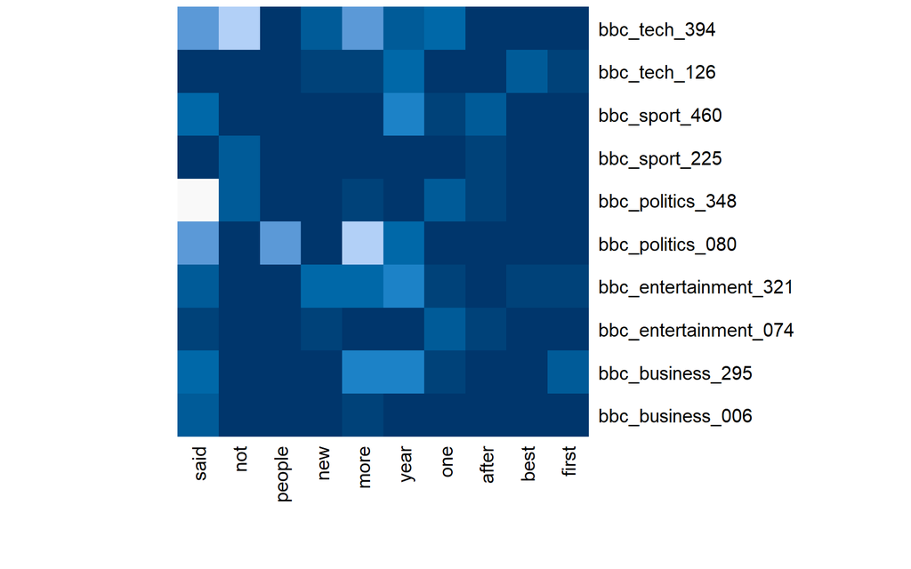

Counts for ten selected articles and ten frequent terms. Rows and columns are not clustered or standardised.

```r
chosen_terms <- head(names(sort(colSums(bbc_C), decreasing = TRUE)), 10)
small <- bbc_C[seq(1, 250, length.out = 10), chosen_terms]
heatmap(small, Rowv = NA, Colv = NA, scale = "none",
        margins = c(7, 8), col = hcl.colors(20, "Blues 3"))
```

## 5.1 Activity A3: Build and inspect the SMS matrix

**Your dataset: SMS. Question:** How sparse is the SMS matrix, and can vocabulary filtering leave a message empty?

Before running R, write a prediction and discuss it with a partner. Then:

1. Build the SMS DTM with `min_df=2`, keeping all message IDs as row names.
2. Report rows, columns, zero fraction and empty rows; list the affected IDs.
3. Reconstruct one nonzero cell directly from that message’s tokens.
4. Make a small heatmap. State which information is no longer recoverable from the DTM.

```r
sms_clean <- word_tokens(sms$text, stop_words = course_stopwords)
C_sms_all <- make_dtm(sms_clean, sms$document_id, min_df = 2)
# Inspect dimensions, row sums, a chosen cell and a small heatmap.
```

**Record and compare:** save the requested output, explain what it shows in two or three sentences, and compare your prediction with a neighbouring group. Agree on one limitation. Rotate who writes the code and who checks the result.

# 6 Frequent and distinctive are different questions

Work with **one corpus at a time**, after choosing its stopwords and retained vocabulary and excluding documents that have no retained terms. Before using the formula, define its ingredients:

- $N$ is the number of **retained documents** in that corpus. The document index is $i=1,\ldots,N$; here one document is one complete article or SMS.
- $V$ is the number of **distinct retained terms** in the common vocabulary. A term is a word form used as a matrix column. The index $t=1,\ldots,V$ identifies the term of interest; $s$ is another index that runs through the same vocabulary when we sum over terms.
- $C_{it}$ is the **number of occurrences** of term $t$ in document $i$. This is a cell of the document-term count matrix $C$; repetitions count.
- $L_i=\sum_{s=1}^{V}C_{is}$ is the total number of **retained token occurrences** in document $i$. It is positive for every retained document. It generally differs from `raw_tokens`, which was calculated before stopword removal and vocabulary filtering.
- $I(C_{it}>0)$ is an **indicator**: it equals 1 if document $i$ contains at least one occurrence of term $t$, and 0 otherwise.

We can now define four related quantities:

$$p_{it}=\frac{C_{it}}{L_i},\qquad
df_t=\sum_{i=1}^{N}I(C_{it}>0),$$

$$idf_t=\log\left(\frac{N}{df_t}\right),\qquad
W_{it}=p_{it}\,idf_t.$$

1. **Term frequency (TF), $p_{it}$:** the proportion of retained tokens in document $i$ that are term $t$. The proportions sum to one within each document. Here TF means a proportion, not a raw count.
2. **Document frequency, $df_t$:** the number of retained documents containing term $t$. Each document contributes at most one, however often it repeats the term. For a retained term, $1\leq df_t\leq N$.
3. **Inverse document frequency (IDF), $idf_t$:** the natural logarithm of $N/df_t$. It is a corpus-level weight, shared by all documents for that term. A term appearing in fewer documents receives a larger IDF; a term appearing in every document has $idf_t=\log(1)=0$.
4. **TF-IDF, $W_{it}$:** the product of the within-document proportion and the corpus-level IDF. The matrix $W$ has the same document rows and term columns as $C$, but its entries are weights rather than counts. A large value identifies a term that is relatively frequent in this document and not widespread across the corpus; it does not establish universal importance.

**A constructed numerical example.** Suppose a term occurs 4 times among 100 retained tokens in one document and occurs in 10 of the corpus’s 50 retained documents. Its TF is $4/100=0.04$, its document frequency is 10, its IDF is $\log(50/10)=\log(5)$, and its TF-IDF in that document is $0.04\log(5)\approx 0.0644$. The four occurrences count four times for TF, but this document contributes only one to document frequency. These numbers illustrate the formula; they are not a measured BBC result.

We use the natural logarithm and no additive smoothing. Software defaults differ, so report this convention and the retained-token denominator. The same count can get different weights in different corpora. If every term appears in every document, all IDFs are zero; a zero TF-IDF vector cannot be normalised for cosine comparisons.

Before normalising, remove and report empty rows once. Use that common document set for all representations. `prepare_text()` performs this check and stops on zero TF-IDF norms rather than inventing values.

```r
demo <- prepare_text(bbc)
lab <- prepare_text(sms)
demo$removed
```

```
#> character(0)
```

```r
lab$removed
```

```
#>  [1] "sms_0887" "sms_2350" "sms_2964" "sms_3399" "sms_3935" "sms_3997"
#>  [7] "sms_4366" "sms_4825" "sms_4938" "sms_5322"
```

```r
R_bbc <- demo$representation
R_sms <- lab$representation
stopifnot(all(abs(rowSums(R_bbc$P) - 1) < 1e-12))
selected_id <- rownames(R_bbc$C)[1]
profile <- data.frame(term = colnames(R_bbc$C),
                      count = R_bbc$C[selected_id, ],
                      tf = R_bbc$P[selected_id, ], idf = R_bbc$idf,
                      tfidf = R_bbc$W[selected_id, ])
head(profile[order(-profile$tfidf), ], 10)
```

|  | term | count | tf | idf | tfidf |
| --- | --- | --- | --- | --- | --- |
| recession | recession | 3 | 0.03030303 | 4.422849 | 0.13402572 |
| japan's | japan's | 2 | 0.02020202 | 4.135167 | 0.08353872 |
| growth | growth | 3 | 0.03030303 | 2.525729 | 0.07653723 |
| economy | economy | 3 | 0.03030303 | 2.385967 | 0.07230202 |
| recovery | recovery | 2 | 0.02020202 | 3.442019 | 0.06953574 |
| technical | technical | 2 | 0.02020202 | 3.324236 | 0.06715629 |
| previously | previously | 2 | 0.02020202 | 2.882404 | 0.05823038 |
| quarter | quarter | 2 | 0.02020202 | 2.748872 | 0.05553277 |
| thought | thought | 2 | 0.02020202 | 2.577022 | 0.05206105 |
| data | data | 2 | 0.02020202 | 2.525729 | 0.05102482 |

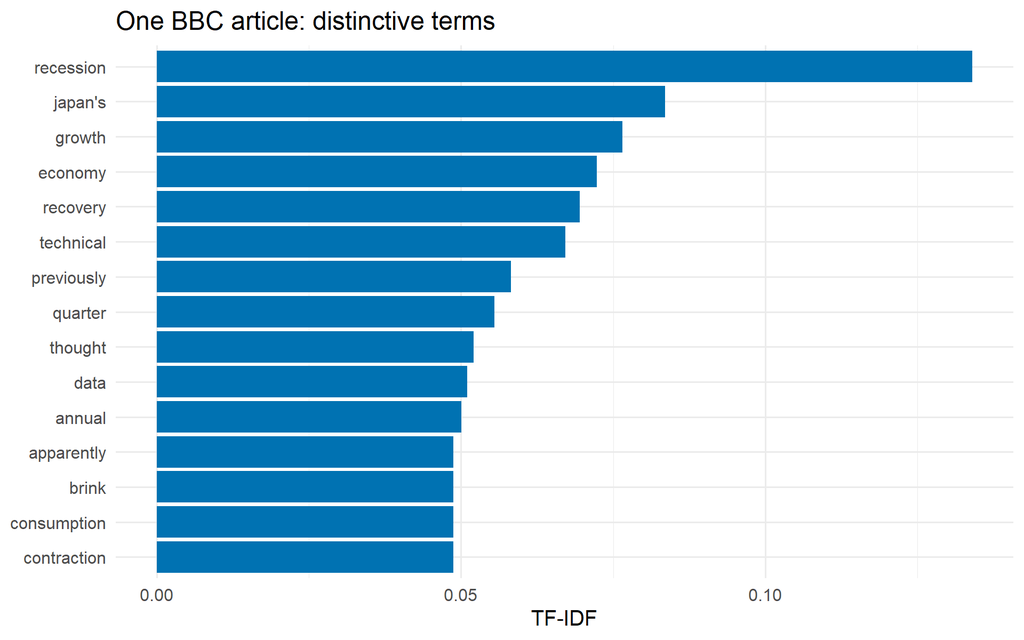

Article-level TF-IDF: a high bar means distinctive within this retained BBC corpus, not universally important.

```r
top_bars(setNames(profile$tfidf, profile$term),
         "One BBC article: distinctive terms", ylab = "TF-IDF")
```

## 6.1 Activity A4: Check TF-IDF by hand

**Your dataset: SMS. Question:** Do the most frequent and the most distinctive words agree for one SMS?

Before running R, write a prediction and discuss it with a partner. Then:

1. Use the already prepared `lab` object. Report retained and excluded message counts.
2. Choose a nonempty message, print its ID, and compare its top counts and TF-IDF terms.
3. For one term, calculate count, denominator, document frequency, IDF and weight directly. Check agreement with the matrix. Explain why merging all messages into one document before computing IDF would fail.

```r
R_sms <- lab$representation
id <- rownames(R_sms$C)[1]
# Choose a term and verify its TF-IDF from the definition.
```

**Record and compare:** save the requested output, explain what it shows in two or three sentences, and compare your prediction with a neighbouring group. Agree on one limitation. Rotate who writes the code and who checks the result.

# 7 A word cloud needs a named quantity

For a topic-level summary, we will average **article-level** TF-IDF values, including zeros for articles without the term. This gives articles equal weight. It differs from pooling tokens, where long articles contribute more.

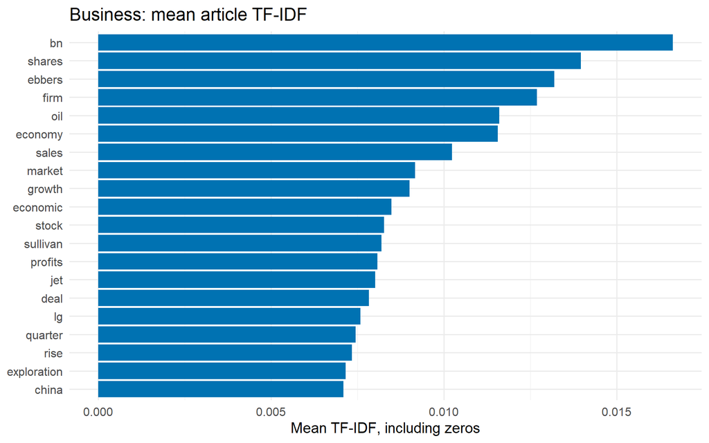

Bars and cloud use the same twenty terms and weights. Cloud position is a layout choice, not a semantic coordinate.

```r
business <- demo$docs$category == "business"
topic_weights <- colMeans(R_bbc$W[business, , drop = FALSE])
shown <- head(sort(topic_weights, decreasing = TRUE), 20)
top_bars(shown, "Business: mean article TF-IDF", n = 20,
         ylab = "Mean TF-IDF, including zeros")
```

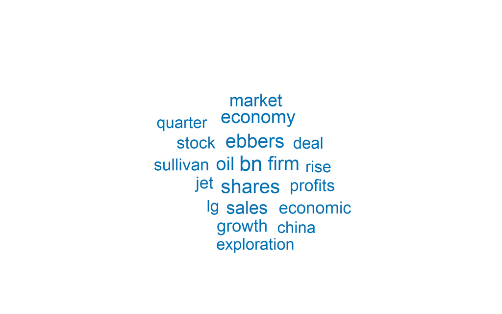

Bars and cloud use the same twenty terms and weights. Cloud position is a layout choice, not a semantic coordinate.

```r
draw_cloud(shown, n = 20, seed = 13)
```

**Reading the figures.** Bars have a common baseline and support direct comparisons. In the cloud, font size encodes weight, but rendered area also depends on word length. Position, proximity and direction have no analytic meaning. The supplied packing helper uses font size proportional to an affine function of square-root weight; it does not promise area-proportional encoding. A cloud is an overview, not a substitute for numerical comparison.

## 7.1 Compare article-level TF-IDF across categories

Does a high-weight word describe only one topic, or is it also prominent in other topics? Use the **same vocabulary and the same article-level IDF** for every category. Do not merge all articles in a category into a single document or recalculate IDF separately within each category: those operations change the question and make the weights refer to different corpora.

Let $g$ be a category, $G_g$ the set of retained documents in that category, and $n_g=|G_g|$ its size. For term $t$, compare

$$\overline W_{gt}=\frac{1}{n_g}\sum_{i\in G_g}W_{it}.$$

Every retained article contributes, including a zero when it does not contain the term. Dividing only by the number of articles containing the word would answer a different question. The category mean gives documents equal weight; it is neither a pooled token proportion nor a probability that an article belongs to that category. Report category sizes alongside the graphs.

```r
# These helpers are defined here, so no change to text_helpers.R is needed.
category_means <- function(W, group) {
  group <- droplevels(factor(group))
  stopifnot(nrow(W) == length(group), !anyNA(group),
            all(is.finite(W)))
  totals <- rowsum(W, group, reorder = TRUE)
  counts <- table(group)
  sweep(totals, 1, as.numeric(counts[rownames(totals)]), "/")
}

category_top_terms <- function(M, n = 3L) {
  unique(unlist(lapply(seq_len(nrow(M)), function(i) {
    values <- sort(M[i, ], decreasing = TRUE)
    head(names(values)[values > 0], n)
  }), use.names = FALSE))
}

plot_category_bars <- function(M, n = 6L, title = "", xlab = "Mean TF-IDF") {
  d <- do.call(rbind, lapply(seq_len(nrow(M)), function(i) {
    values <- sort(M[i, ], decreasing = TRUE)
    values <- head(values[values > 0], n)
    if (!length(values)) return(NULL)
    data.frame(category = rownames(M)[i], term = names(values),
               weight = as.numeric(values))
  }))
  if (is.null(d)) stop("No positive weights to plot")
  d$key <- paste(d$category, d$term, sep = " || ")
  d$key <- factor(d$key, levels = rev(unique(d$key)))
  labels <- setNames(d$term, as.character(d$key))
  ggplot(d, aes(weight, key)) + geom_col(fill = blue) +
    facet_wrap(~ category, scales = "free_y", ncol = 3) +
    scale_y_discrete(labels = function(x) unname(labels[x])) +
    labs(title = title, x = xlab, y = NULL)
}

plot_category_heatmap <- function(M, terms, title = "",
                                   fill_title = "Mean TF-IDF") {
  stopifnot(length(terms) > 0, all(terms %in% colnames(M)))
  d <- as.data.frame(as.table(M[, terms, drop = FALSE]))
  names(d) <- c("category", "term", "weight")
  d$term <- factor(d$term, levels = rev(terms))
  ggplot(d, aes(category, term, fill = weight)) +
    geom_tile(colour = "grey90") +
    scale_fill_gradient(low = "white", high = blue, name = fill_title) +
    labs(title = title, x = "Category", y = NULL)
}
```

```r
stopifnot(identical(rownames(R_bbc$W), demo$docs$document_id))
table(demo$docs$category)
```

```
#>
#>      business entertainment      politics         sport          tech
#>            50            50            50            50            50
```

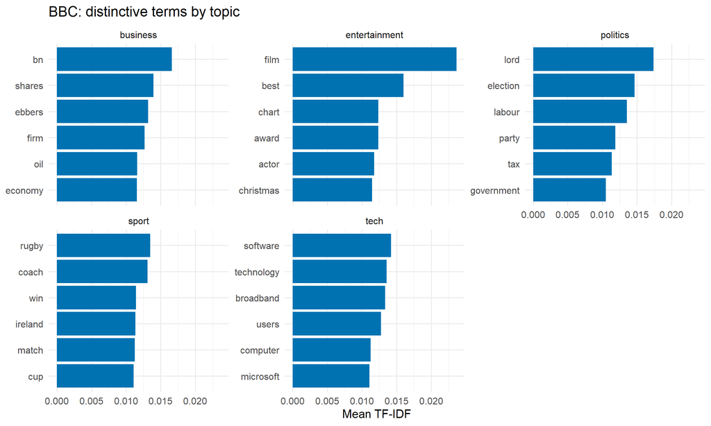

The six highest mean article-level TF-IDF terms within each BBC category. The horizontal scale is shared; term labels can differ between panels.

```r
bbc_category_tfidf <- category_means(R_bbc$W, demo$docs$category)
plot_category_bars(bbc_category_tfidf,
                    title = "BBC: distinctive terms by topic")
```

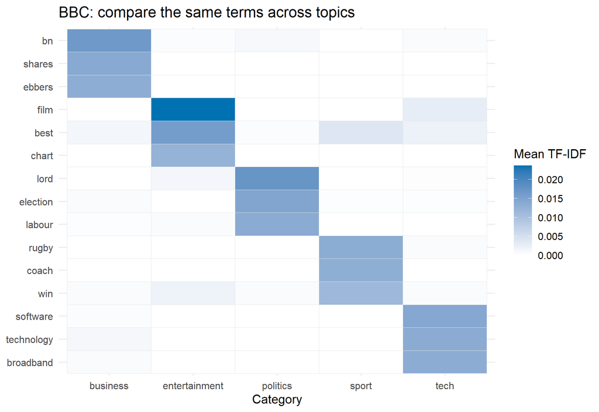

The union of the top three terms per category is shown in every category, including zeros. All cells use one common TF-IDF colour scale.

```r
comparison_terms <- category_top_terms(bbc_category_tfidf, n = 3)
plot_category_heatmap(bbc_category_tfidf, comparison_terms,
                       title = "BBC: compare the same terms across topics")
```

**Reading the comparison.** The panels identify high-weight terms within each topic. The heatmap then compares a **common set of terms** across topics: a word omitted from another panel’s top six is not necessarily absent there. Check one word with a direct average, including its zero entries:

```r
word <- comparison_terms[1]
stopifnot(isTRUE(all.equal(
  unname(bbc_category_tfidf["business", word]),
  mean(R_bbc$W[demo$docs$category == "business", word])
)))
```

Before drawing a content conclusion, read articles contributing to a selected high-weight cell. Names or reporting conventions can be distinctive without being a complete account of a topic. These are descriptive contrasts, not estimates of classification accuracy or causal effects.

## 7.2 Activity A5: Compare categories and displays

**Your dataset: SMS. Question:** Which display better answers a precise comparison between two terms?

Before running R, write a prediction and discuss it with a partner. Then:

1. Compute mean message-level TF-IDF for spam, including absent-term zeros.
2. Select the same twenty positive terms for a bar chart and cloud.
3. Ask a neighbouring pair to rank two similarly weighted terms using only one display. Check their answer against the values; swap displays.
4. State the document group, denominator, weights, and cloud-size rule in a caption.
5. Compute mean message-level TF-IDF for **both ham and spam**, using `R_sms$W` and the matching rows of `lab$docs`. Keep the common SMS-level IDF and include absent-term zeros. Report the retained message count in each label; the original balanced sample need not remain balanced after filtering.
6. Make a two-category bar comparison and a heatmap for the union of each label’s top three terms. Use common weight scales. Select one term and verify its mean directly, including messages where it is absent.
7. Describe one shared term and one contrasting term, checking the original messages. Explain why these weights are not probabilities of spam.

```r
is_spam <- lab$docs$category == "spam"
# First compare the same twenty spam weights in bars and a cloud.
sms_category_tfidf <- category_means(R_sms$W, lab$docs$category)
# Then use plot_category_bars() and plot_category_heatmap() for ham versus spam.
# State the category denominators and verify one cell independently.
```

**Record and compare:** save the requested output, explain what it shows in two or three sentences, and compare your prediction with a neighbouring group. Agree on one limitation. Rotate who writes the code and who checks the result.

# 8 Recover a little order with n-grams

A bigram is a pair of adjacent tokens; a trigram has three. Extract them **before** deleting words, and avoid crossing sentence or document boundaries. Only afterwards filter n-grams containing stopwords. Otherwise removing `of` from the constructed phrase `bank of england` would invent `bank england`. The phrase is a teaching illustration, not an extracted BBC quotation.

```r
phrase <- "bank of england"
sentence_ngrams(phrase, filter_stop = FALSE)
```

```
#> [1] "bank of"    "of england"
```

```r
word_tokens(phrase, stop_words = course_stopwords)
```

```
#> [[1]]
#> [1] "bank"    "england"
```

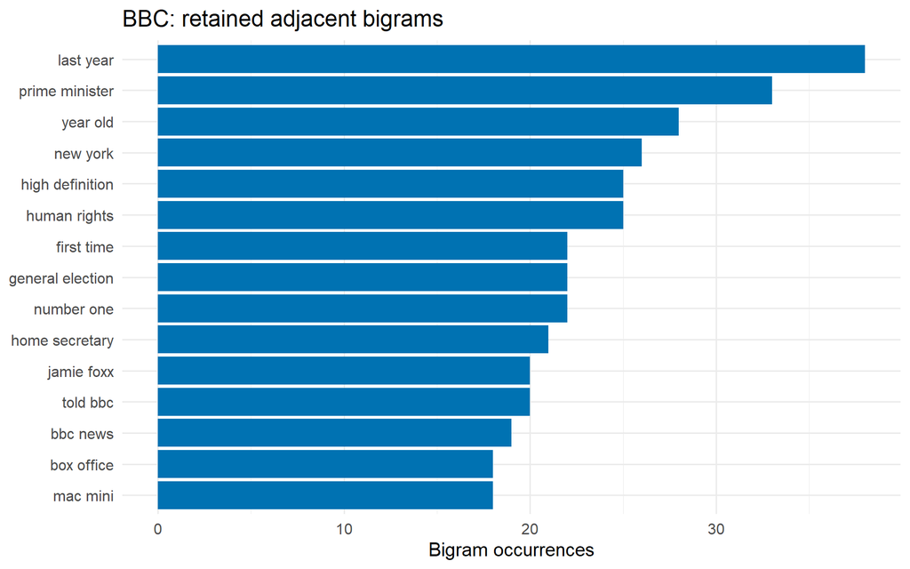

Bigrams are adjacent retained word sequences from within approximate sentence boundaries.

```r
bbc_bigrams <- lapply(bbc$text, sentence_ngrams)
bigram_counts <- term_counts(bbc_bigrams)
top_bars(setNames(bigram_counts$count, bigram_counts$term),
         "BBC: retained adjacent bigrams", ylab = "Bigram occurrences")
```

Our sentence splitter is punctuation-based; abbreviations and unusual SMS punctuation can defeat it. The baseline word rule also ignores punctuation inside a sentence. Read contextual examples before treating any pair as a linguistically validated expression. With `mr` in the stopword list, a bigram containing it is filtered out **after extraction**. For example, the constructed sequence `said mr smith` yields no retained bigram from these two pairs; it must not be converted into the invented adjacency `said smith`. Thus `mr` is absent from the filtered bigram network, without reconnecting the words that surrounded it. Same-document co-occurrence is a different relationship from adjacency and can connect words many sentences apart.

## 8.1 Compare n-gram profiles across article categories

Apply the same question to adjacent expressions: which bigrams are distinctive of each topic, and how widely are they shared? Preserve **one row per document** and build a common bigram vocabulary. Repeated occurrences contribute to counts, whereas document presence records whether a pair occurs at least once.

We use two complementary summaries:

- **Mean document-level bigram TF-IDF**, with one global article-level IDF computed for the whole comparison corpus, not one IDF per topic.
- **Document prevalence:** the percentage of documents in the category that contain the bigram at least once. It lies between 0 and 100 and does not increase when a single document repeats the same pair many times.

For this descriptive comparison, keep the same document IDs as the unigram analysis (`demo$docs`, or `lab$docs` in the SMS exercise). Some of these texts may have no bigram surviving `min_df=2`. Report their counts by category. Their presence indicators and their contribution to the **category-average** TF-IDF are set to zero. For other documents, TF divides by the number of retained bigram occurrences in that document. IDF uses all documents in this comparison, including those with no retained bigram. This explicit zero-row convention is for category summaries: an empty row is not a normalised probability profile and must not be sent into the distance calculations of Unit 14. No new document is silently removed here.

```r
ngram_category_profiles <- function(docs, n = 2L, min_df = 2L) {
  grams <- lapply(docs$text, sentence_ngrams, n = n)
  C <- make_dtm(grams, docs$document_id, min_df = min_df)
  totals <- rowSums(C)
  nonempty <- totals > 0
  P <- matrix(0, nrow(C), ncol(C), dimnames = dimnames(C))
  P[nonempty, ] <- C[nonempty, , drop = FALSE] / totals[nonempty]
  idf <- log(nrow(C) / colSums(C > 0))
  W <- sweep(P, 2, idf, "*")
  audit <- do.call(rbind, lapply(split(seq_len(nrow(docs)), docs$category),
    function(i) data.frame(documents = length(i),
                           no_retained_ngram = sum(!nonempty[i]))))
  stopifnot(all(is.finite(W)), all(W[!nonempty, , drop = FALSE] == 0))
  list(counts = C, weights = W, audit = audit,
       mean_tfidf = category_means(W, docs$category),
       prevalence = category_means(100 * (C > 0), docs$category))
}
```

```r
bbc_bigram_profiles <- ngram_category_profiles(demo$docs, n = 2)
knitr::kable(bbc_bigram_profiles$audit, row.names = TRUE)
```

|  | documents | no_retained_ngram |
| --- | --- | --- |
| business | 50 | 0 |
| entertainment | 50 | 0 |
| politics | 50 | 0 |
| sport | 50 | 0 |
| tech | 50 | 0 |

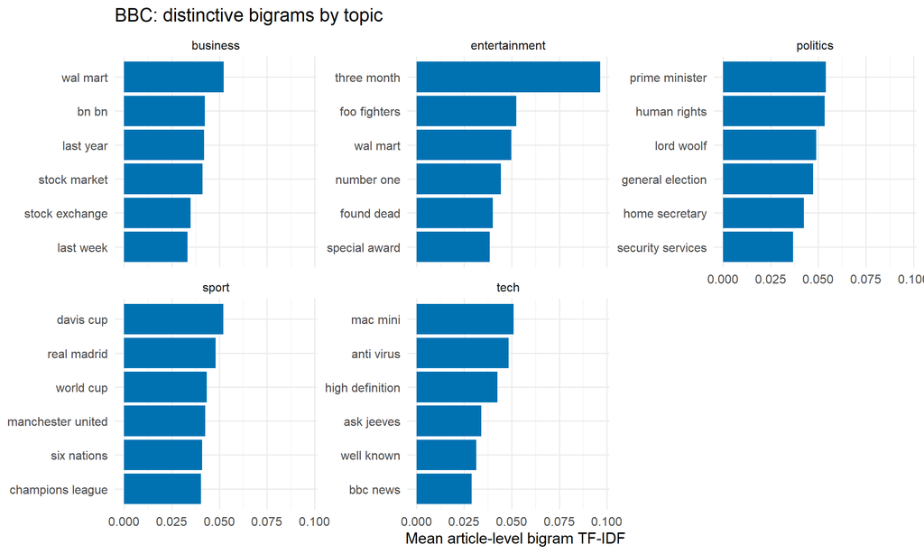

Bigram TF-IDF contrasts across BBC topics. The IDF vocabulary and document corpus are common to all categories; absent pairs contribute zeros to category means.

```r
plot_category_bars(bbc_bigram_profiles$mean_tfidf,
                    title = "BBC: distinctive bigrams by topic",
                    xlab = "Mean article-level bigram TF-IDF")
```

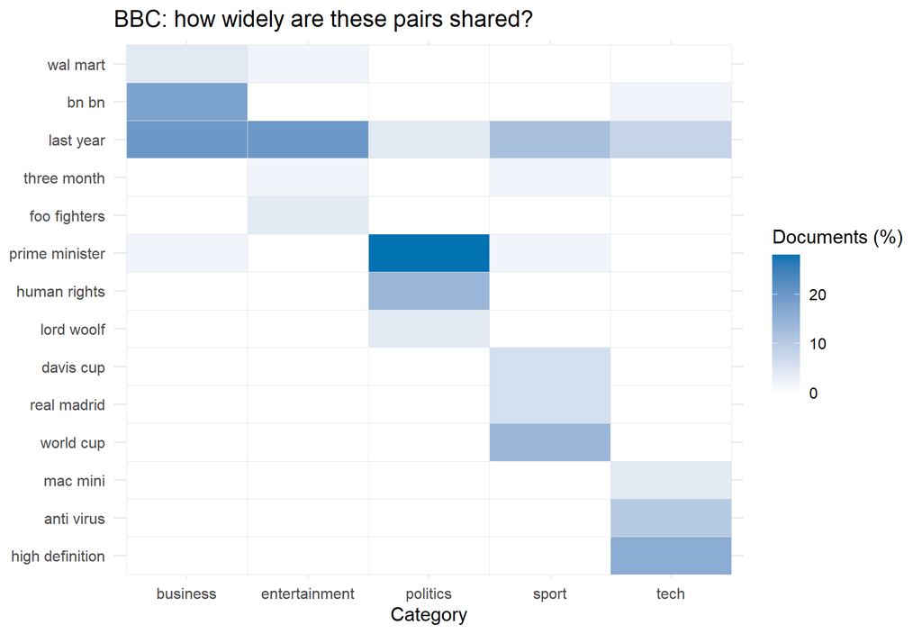

For a common set of selected bigrams, each cell gives the percentage of articles containing the pair. Repeated occurrences in the same article count only once.

```r
comparison_bigrams <- category_top_terms(bbc_bigram_profiles$mean_tfidf, n = 3)
plot_category_heatmap(bbc_bigram_profiles$prevalence, comparison_bigrams,
                       title = "BBC: how widely are these pairs shared?",
                       fill_title = "Documents (%)")
```

**Interpretation.** A high mean TF-IDF can identify an expression concentrated in a subset of documents; prevalence tells us whether it is widespread within the category. These quantities have different units, so do not compare their numerical sizes directly. A word pair absent from a top-term panel may still occur in that category: use the common-term heatmap and original texts. Longer documents also offer more opportunities for a pair to appear, so prevalence does not fully adjust for document length. Keep that limitation alongside the length plots from Activity A1. To investigate trigrams, repeat the same function with `n=3`, retaining the same IDs and reporting the new empty-profile counts; do not infer trigram counts from bigram paths.

## 8.2 From bigram counts to a directed word network

The bigram table also defines a **directed network**:

- A **node** is a distinct word form, not an individual token occurrence.
- An **arrow** from word $a$ to word $b$ means that $b$ follows $a$ in at least one extracted bigram. The reverse order would be a different arrow.
- The **edge weight** is the number of occurrences of that ordered pair across the corpus. Thicker arrows represent more occurrences. A separate `documents` column counts how many different texts contain the pair.

The network retains the within-sentence extraction and stopword rules above. It is an adjacency network, not a same-document co-occurrence network and not a diagram of causal effects.

```r
bbc_edges <- bigram_edges(bbc_bigrams, min_count = 10, top_n = 40)
head(bbc_edges)
```

|  | from | to | count | documents |
| --- | --- | --- | --- | --- |
| 1 | last | year | 38 | 32 |
| 2 | prime | minister | 33 | 16 |
| 3 | year | old | 28 | 23 |
| 4 | new | york | 26 | 18 |
| 5 | high | definition | 25 | 8 |
| 6 | human | rights | 25 | 7 |

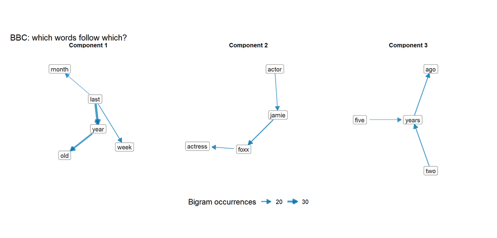

BBC directed bigram network. Arrow width encodes occurrences. Shown: the three largest components with at least three words, after retaining at most forty non-self bigrams occurring at least ten times. Panels separate disconnected parts of this filtered graph.

```r
bbc_network <- plot_bigram_network(bbc_edges, max_components = 3,
                                   title = "BBC: which words follow which?")
bbc_network$plot
```

**Reading the network.** Follow the arrowheads to read order. With `mr` removed, the selected components show recurring time expressions, such as branches through `last` and `year`, a name-and-role sequence involving `actor`, `jamie`, `foxx` and `actress`, and expressions ending in `years ago`. A well-connected word can reflect how articles refer to time rather than their main topic. These components suggest expressions to investigate; they are not automatically discovered topics or semantic clusters.

The former reporting pattern through `mr` is no longer part of this graph. Its removal changes which edges and components enter the top-forty display, so component numbers and prominent nodes must be read from the current plot. It does not mean that the underlying articles stopped containing forms of address or reporting language.

To keep labels readable, the display selects frequent edges, omits repeated-word self-loops, and shows only the three largest components of at least three nodes. A component is a set connected when arrow direction is ignored. The original bigram table is unchanged. A missing edge or disconnected panel can be a consequence of the display filter; it does not prove absence from the full corpus. The layout separates labels: geometric distance and edge crossings have no semantic meaning. All plotting code is in the supplied helper file; no extra R package is required.

## 8.3 Let paths suggest longer n-grams, then verify them

A directed path $a\to b\to c$ suggests the candidate trigram `a b c`. But its two edges may come from different sentences or different documents: their presence does **not** establish that all three words occurred together. Even if both edges are frequent, the longer phrase can be absent. Extract trigrams from the original texts to answer that question.

```r
candidates <- candidate_trigrams(bbc_network$edges)
path_check <- verify_phrases(candidates, bbc$text, n = 3)
knitr::kable(path_check, row.names = FALSE,
             caption = "Candidate three-word paths and their actual within-sentence trigram counts.")
```

Candidate three-word paths and their actual within-sentence trigram counts.

| phrase | actual_occurrences |
| --- | --- |
| jamie foxx actress | 14 |
| actor jamie foxx | 14 |
| last year old | 0 |
| two years ago | 5 |
| five years ago | 2 |

**Interpretation.** Under the current stopword rule, `last year old` has count zero even though the graph contains `last` to `year` and `year` to `old`. Those two observed pairs do not establish one three-word expression. In contrast, candidates such as `two years ago` and `actor jamie foxx` are verified in the original ordered tokens. Read the computed table for the current counts rather than inferring them from edge widths.

The graph is therefore useful for proposing expressions; the ordered source tokens decide whether those expressions really occur. The name-and-role component also suggests a path with three arrows and four words:

```r
verify_phrases("actor jamie foxx actress", bbc$text, n = 4)
```

| phrase | actual_occurrences |
| --- | --- |
| actor jamie foxx actress | 14 |

This four-gram is checked as an actual sequence, rather than inferred by multiplying edge weights or taking their minimum. Bigram weights alone do not determine trigram or four-gram frequencies. Longer n-grams retain more context but usually have less support. Compare the count of an expression with the number of source documents containing it before calling it a general pattern. Changing an edge threshold can also break a visible path without changing any original text.

## 8.4 Explore each category’s three main word networks

Build the bigram network **separately within each category**. Here we choose entertainment and politics. Each category supplies its own frequent pairs, nodes, connected components and layout; neither graph is constrained to the pooled BBC network.

For a reproducible meaning of “main”, retain at most forty non-self bigrams occurring at least three times **within the category**, then show the three largest components containing at least three words. Components are ranked by their number of distinct words, not by semantic importance. The two categories use the same selection rule but can yield completely different networks.

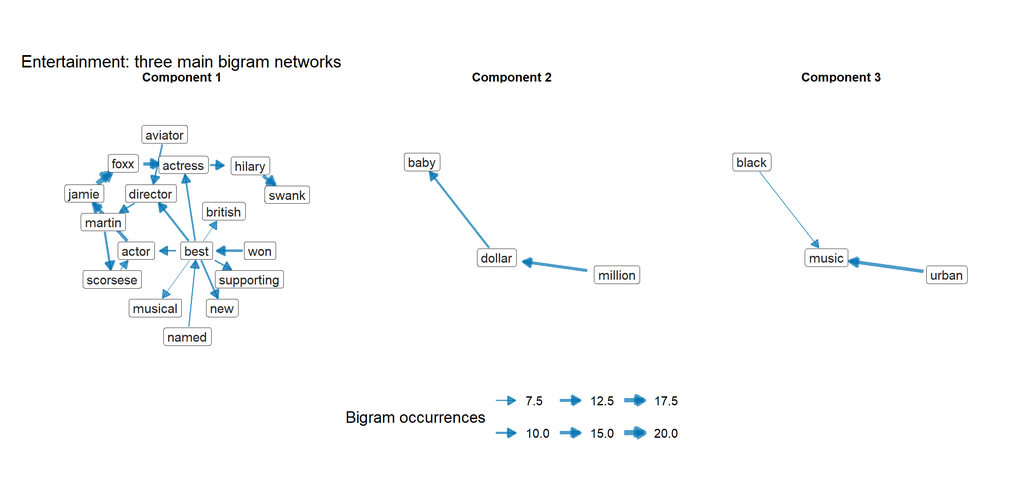

Entertainment: the three largest eligible components of its own top-forty bigram graph. Pairs must occur at least three times in entertainment articles. Arrows show order and widths show within-category occurrence counts.

```r
entertainment_bigrams <- bbc_bigrams[bbc$category == "entertainment"]
entertainment_edges <- bigram_edges(entertainment_bigrams,
                                    min_count = 3, top_n = 40)
entertainment_network <- plot_bigram_network(entertainment_edges,
  max_components = 3, title = "Entertainment: three main bigram networks")
entertainment_network$plot
```

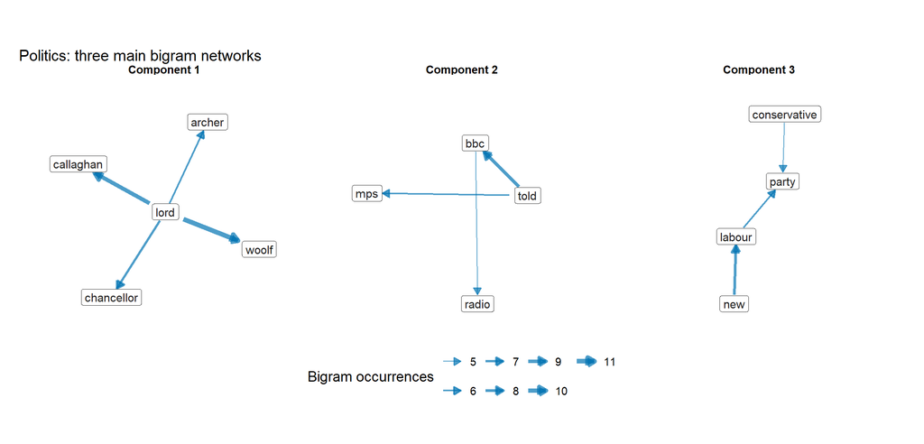

Politics: an independently selected and laid-out graph, using the same minimum count and top-forty rule. The three components are selected within politics, not copied from entertainment or from the pooled corpus.

```r
politics_bigrams <- bbc_bigrams[bbc$category == "politics"]
politics_edges <- bigram_edges(politics_bigrams,
                               min_count = 3, top_n = 40)
politics_network <- plot_bigram_network(politics_edges,
  max_components = 3, title = "Politics: three main bigram networks")
politics_network$plot
```

**Interpretation.** Entertainment now brings out its own names, award-related phrases and titles; politics brings out its own political names, institutions and expressions. Identify a connected sequence in each category and check whether a longer expression really occurs in its source articles. With `mr` filtered out, an honorific is not a node to interpret in either graph.

These plots are exploratory summaries of each category’s recurring language. Component numbers and node positions are local to each plot and are not matched across categories. Read the count legends rather than treating equal drawn widths as equal counts across plots. Each category contains fifty articles, but their lengths and repetition patterns can still differ. A missing expression may have fallen below the threshold or outside the top forty: use the category tables and source texts before claiming absence.

## 8.5 Activity A6: From a network to longer phrases

**Your dataset: SMS. Question:** Which longer expressions does a bigram network suggest, and which actually occur?

For all comparisons in this activity, use the retained messages in `lab$docs`, with the same IDs as `R_sms$W`. This keeps unigram, bigram and network category denominators aligned; report the original excluded messages as in A4. When reading source messages, match by `document_id`.

Before running R, write a prediction and discuss it with a partner. Then:

1. Count within-message, within-sentence bigrams and plot ten frequent pairs.
2. Build a directed network with `min_count=2`, `top_n=40` and at most three displayed components. State what its nodes, arrows, widths and filters mean.
3. Follow two arrows to propose a three-word phrase. Predict whether it really occurs, then use `candidate_trigrams()` and `verify_phrases()` to check it. Explain why two positive edge counts alone cannot answer this question.
4. Locate two original messages containing a repeated pair and verify adjacency. Compare its occurrence count with its `documents` count.
5. If the displayed graph has a three-arrow path, propose a four-gram and check it with `n=4`. Otherwise, explain how a display threshold can hide such paths.
6. Replot with `min_count=4`, keeping `top_n=40`. Describe which visible connections change. Retain the extraction order: do not delete stopwords before identifying adjacent sequences.
7. Compare bigrams between **ham and spam** using `ngram_category_profiles(lab$docs, n=2)`. Report label sizes and texts with no retained bigram; draw category TF-IDF bars and a common-pair prevalence heatmap. Explain why occurrences and document prevalence can disagree.
8. Split `sms_bigrams` by `lab$docs$category` and build **separate ham and spam networks**, following the entertainment/politics example. In each label, select its own frequent edges and show up to three main components; do not reuse the pooled graph’s nodes or layout. Start with `min_count=2` and `top_n=40`, and inspect how many eligible components remain. If fewer than three exist, report that result; if none has three words, do not call the plot helper with an empty selection. You may explore `min_count=1` as a clearly labelled sensitivity analysis, noting the weaker support. Compare the expression types suggested by the plots, verify a pair in original messages, and state the message counts in each label. Repeat the profile comparison for trigrams if time permits.

```r
sms_bigrams <- lapply(lab$docs$text, sentence_ngrams)
sms_edges <- bigram_edges(sms_bigrams, min_count = 2, top_n = 40)
# Draw the pooled network, propose paths, check n-grams and source messages.
# For category plots, split these lists and fit each label's network afresh.
ham_bigrams <- sms_bigrams[lab$docs$category == "ham"]
spam_bigrams <- sms_bigrams[lab$docs$category == "spam"]
# Inspect bigram_edges() in each label before choosing the plotting threshold.
sms_bigram_profiles <- ngram_category_profiles(lab$docs, n = 2)
# Compare its mean_tfidf and prevalence matrices for ham and spam.
# Keep lab$docs$category matched to these same retained SMS rows.
```

**Record and compare:** save the requested output, explain what it shows in two or three sentences, and compare your prediction with a neighbouring group. Agree on one limitation. Rotate who writes the code and who checks the result.

# 9 Sensitivity: a threshold changes what can be represented

The document-frequency threshold is part of the feature definition. Compare BBC thresholds before choosing the more attractive plot.

```r
bbc_df5 <- make_dtm(bbc_clean, bbc$document_id, min_df = 5)
data.frame(min_df = c(2,5),
           vocabulary = c(ncol(bbc_C), ncol(bbc_df5)),
           empty = c(sum(rowSums(bbc_C)==0), sum(rowSums(bbc_df5)==0)))
```

| min_df | vocabulary | empty |
| --- | --- | --- |
| 2 | 5026 | 0 |
| 5 | 1996 | 0 |

## 9.1 Activity A7: Audit a vocabulary change

**Your dataset: SMS. Question:** What changes when the SMS minimum document frequency rises from two to five?

Before running R, write a prediction and discuss it with a partner. Then:

1. Use the same tokens and all 240 IDs to build the two matrices.
2. Compare vocabulary size, empty rows, and which original messages lose all features.
3. Identify a meaningful term removed by the stronger filter and justify whether you would keep it. Separate changed vocabulary from changed document inclusion.
4. Explain why later map comparisons must use a common retained document set.

```r
C2 <- make_dtm(sms_clean, sms$document_id, min_df = 2)
C5 <- make_dtm(sms_clean, sms$document_id, min_df = 5)
# Compare terms, empty rows and IDs; inspect one affected original.
```

**Record and compare:** save the requested output, explain what it shows in two or three sentences, and compare your prediction with a neighbouring group. Agree on one limitation. Rotate who writes the code and who checks the result.

# 10 Bring the choices together

Before moving to distances, keep the document IDs, feature definitions and weights together. A visually distinctive word may be a name, a formatting artifact or a rare spelling; an appealing cloud does not validate the pipeline.

# 11 Check your understanding

**Q1.** A term occurs ten times in one document and once in each of ten other documents. What are its total count and document frequency?

**Q2.** Why can a word have a positive count but zero TF-IDF?

**Q3.** Does proximity in a word cloud imply semantic similarity?

**Q4.** Why retain complete messages as rows even when extracting sentence-level n-grams?

**Q5.** If both `a b` and `b c` occur in the corpus, must `a b c` occur? How would you check rather than infer it from the network?

# 12 Take-home messages

- A corpus is a collection of defined observational units, not just a bag of files.
- Preprocessing changes the variables; record the choices and inspect original texts.
- Counts, proportions and TF-IDF answer different questions.
- Category contrasts need a common vocabulary and IDF, stated denominators, absent-term zeros, and common graphical scales.
- N-gram occurrence counts and document prevalence describe different aspects of an expression. Separate category networks can reveal different recurring phrases; report their selection rules and interpret their own legends.
- A word cloud needs explicit weights and does not supply a semantic geometry.
- Adjacent n-grams must be extracted before word deletion; verify their context.
- Directed bigram paths suggest longer phrases but cannot establish their presence or frequency. Check the original ordered tokens.
- Empty profiles must be handled explicitly before comparing documents.

# 13 Sources and further reading

- [BBC dataset and attribution](https://github.com/derekgreene/bbc-datasets). Greene and Cunningham (2006), ICML. Original article copyright remains BBC; the distributor specifies non-commercial and research use.
- [SMS Spam Collection](https://archive.ics.uci.edu/dataset/228/sms+spam+collection). Almeida and Hidalgo (2011), UCI, DOI 10.24432/C5CC84; CC BY 4.0.
- Silge and Robinson, [Text Mining with R](https://www.tidytextmining.com/): word frequencies, TF-IDF and n-grams.
- R documentation: [classical MDS](https://stat.ethz.ch/R-manual/R-devel/library/stats/html/cmdscale.html) and [correspondence analysis](https://stat.ethz.ch/R-manual/R-devel/library/MASS/html/corresp.html).

See `data/text_corpora_sources.txt` and `data/text_corpora_manifest.json` for selection, deduplication, source identifiers, seeds and file hashes. The supplied CSVs are fixed classroom inputs. Both are balanced teaching subsets, not estimates of real category prevalence. No download occurs while knitting.

# 14 Reproducibility information

> **Note on AI assistance**

> These teaching materials were prepared with assistance from ChatGPT (OpenAI) in drafting explanations, developing examples, and generating R code. The author retains responsibility for the final content.